# Project with Global Finance Corp. (GFC), focusing on developing an AI-powered chatbot to revolutionize their financial data analysis.

### Project context:

Our goal is to extract meaningful insights from 10-K financial reports. These insights will feed into the AI chatbot, enabling it to provide in-depth financial performance analysis.

### Objective

Extract key financial data for the last three fiscal years from the 10-K filings of Microsoft, Tesla, and Apple. Use Python to analyze this data, focusing on trends and insights that could inform the development of an AI-powered financial chatbot.

The following financial figures are to be extracted and used for the analysis: Total Revenue, Net Income, Total Assets, Total Liabilities, and Cash Flow from Operating Activities.

### Data Description

The data contains Total Revenue, Net Income, Total Assets, Total Liabilities, and Cash Flow from Operating Activities.

### Data Dictionary

- EIN: Unique Employer ID of the company with the IRS
- Company_Name: Name of the company
- Year: Year for each company For each company, the financial data for the last three fiscal years.
- Total_Revenue: Total Revenue for each company for the last three fiscal years
- Net_Income: Net Income for each company for the last three fiscal years
- Total_Assets: Total Assets for each company for the last three fiscal years
- Total_Liabilities: Total Liabilities for each company for the last three fiscal years
- Cash Flow from Operating Activities: Cash Flow from Operating Activities for each company for the last three fiscal years

### Importing the required libraries

```python
# to suppress warnings
import warnings
warnings.filterwarnings("ignore")
```

```python
# Installing the libraries with the specified version.
!pip install numpy==1.25.2 pandas==1.5.3 matplotlib==3.7.1 seaborn==0.13.1 -q --user
```

```python
# Libraries to help with data reading and data manipulation
import numpy as np
import pandas as pd

# Libraries to help with data visualization
import matplotlib.pyplot as plt
import seaborn as sns
```

### Loading the dataset

```python
# Code to restrict float to 2 decimal places
pd.set_option('display.float_format', lambda x: '%.2f' % x)
```

```python
# uncomment and run the following lines for Google Colab
# from google.colab import drive
# drive.mount('/content/drive')
```

```python
# Code to let colab access my google drive
from google.colab import drive
drive.mount('/content/drive')
```

```python
# Code to read the data
data =pd.read_csv('/content/drive/MyDrive/10_K_Financials.csv')
```

```python
# Code to view the first 5 rows of the dataset
data.head()
```

|  | EIN | Company_Name | Year | Total_Revenue | Net_Income | Total_Assets | Total_Liabilities | Cash Flow_Operating Activities |
| --- | --- | --- | --- | --- | --- | --- | --- | --- |
| 0 | 91-1144442 | Microsoft | 2022 | 198270 | 72738 | 364840 | 198298 | 89035 |
| 1 | 91-1144443 | Microsoft | 2023 | 211915 | 72361 | 411976 | 205753 | 87582 |
| 2 | 91-1144444 | Microsoft | 2024 | 245122 | 88136 | 512163 | 243686 | 118548 |
| 3 | 91-2197729 | Tesla | 2022 | 81462 | 12587 | 82338 | 36440 | 14724 |
| 4 | 91-2197730 | Tesla | 2023 | 96773 | 14974 | 106618 | 43009 | 13256 |

```python
# Code to view the last 5 rows of the dataset
data.tail()
```

|  | EIN | Company_Name | Year | Total_Revenue | Net_Income | Total_Assets | Total_Liabilities | Cash Flow_Operating Activities |
| --- | --- | --- | --- | --- | --- | --- | --- | --- |
| 4 | 91-2197730 | Tesla | 2023 | 96773 | 14974 | 106618 | 43009 | 13256 |
| 5 | 91-2197731 | Tesla | 2024 | 97690 | 7153 | 122070 | 48390 | 14923 |
| 6 | 94-2404110 | Apple | 2022 | 394328 | 99803 | 352755 | 302083 | 122151 |
| 7 | 94-2404111 | Apple | 2023 | 383285 | 96995 | 352583 | 290437 | 110543 |
| 8 | 94-2404112 | Apple | 2024 | 391035 | 93736 | 364980 | 308030 | 118254 |

*Observations*

The dataset has been properly loaded and ready for use.

### Checking the shape of the dataset

```python
# Code to check the shape of the dataset
num_rows, num_cols = data.shape

# Adding narrative to the output
print(f"The dataset has {num_rows} rows and {num_cols} columns.")
print(f"This means there are {num_rows} observations and {num_cols} features in the dataset.")
```

```
The dataset has 9 rows and 8 columns.
This means there are 9 observations and 8 features in the dataset.
```

```python
# Converting data type of the year column to object
data['Year'] = data['Year'].astype('object')
```

### Checking the data types of the columns for the dataset

```python
# Code to check the data types of the columns in the dataset
data.info()
```

```
<class 'pandas.core.frame.DataFrame'>
RangeIndex: 9 entries, 0 to 8
Data columns (total 8 columns):
 #   Column                          Non-Null Count  Dtype
---  ------                          --------------  -----
 0   EIN                             9 non-null      object
 1   Company_Name                    9 non-null      object
 2   Year                            9 non-null      object
 3   Total_Revenue                   9 non-null      int64
 4   Net_Income                      9 non-null      int64
 5   Total_Assets                    9 non-null      int64
 6   Total_Liabilities               9 non-null      int64
 7   Cash Flow_Operating Activities  9 non-null      int64
dtypes: int64(5), object(3)
memory usage: 708.0+ bytes
```

*Observations*

The dataset has three objects (categorical variables) and five integers (numerical variables), with a memory usage of 708.0+ bytes

```python
print(data['Year'].dtype)
```

```
object
```

```python
# Code to check duplicated values in the dataset
data.duplicated().sum()
```

```
0
```

*Observations*

There are no duplicates in the dataset.

```python
#Code to check missing values in the dataset
data.isnull().sum()
```

|  | 0 |
| --- | --- |
| EIN | 0 |
| Company_Name | 0 |
| Year | 0 |
| Total_Revenue | 0 |
| Net_Income | 0 |
| Total_Assets | 0 |
| Total_Liabilities | 0 |
| Cash Flow_Operating Activities | 0 |

**dtype:** int64

*Observations* There are no missing values in the dataset.

### Creating a copy of original data

```python
data_copy = data.copy()
```

### Statistical summary of the dataset

```python
# Code to check the statistical summary of the dataset
data.describe().T
```

|  | count | mean | std | min | 25% | 50% | 75% | max |
| --- | --- | --- | --- | --- | --- | --- | --- | --- |
| Total_Revenue | 9.00 | 233320.00 | 130006.97 | 81462.00 | 97690.00 | 211915.00 | 383285.00 | 394328.00 |
| Net_Income | 9.00 | 62053.67 | 39095.86 | 7153.00 | 14974.00 | 72738.00 | 93736.00 | 99803.00 |
| Total_Assets | 9.00 | 296702.56 | 153240.42 | 82338.00 | 122070.00 | 352755.00 | 364980.00 | 512163.00 |
| Total_Liabilities | 9.00 | 186236.22 | 114506.22 | 36440.00 | 48390.00 | 205753.00 | 290437.00 | 308030.00 |
| Cash Flow_Operating Activities | 9.00 | 76557.33 | 48272.77 | 13256.00 | 14923.00 | 89035.00 | 118254.00 | 122151.00 |

```python
# Code to calculate the sum of key financial metrics (Total Revenue, Net Income, Total Assets, Total Liabilities, and Cash Flow from Operating Activities) for each company (Apple, Microsoft, Tesla) across different years
company_year_stats = data.groupby(['Company_Name', 'Year'])[['Total_Revenue', 'Net_Income', 'Total_Assets', 'Total_Liabilities', 'Cash Flow_Operating Activities']].sum()
print(company_year_stats)
```

```
                   Total_Revenue  Net_Income  Total_Assets  Total_Liabilities  \
Company_Name Year
Apple        2022         394328       99803        352755             302083
             2023         383285       96995        352583             290437
             2024         391035       93736        364980             308030
Microsoft    2022         198270       72738        364840             198298
             2023         211915       72361        411976             205753
             2024         245122       88136        512163             243686
Tesla        2022          81462       12587         82338              36440
             2023          96773       14974        106618              43009
             2024          97690        7153        122070              48390

                   Cash Flow_Operating Activities
Company_Name Year
Apple        2022                          122151
             2023                          110543
             2024                          118254
Microsoft    2022                           89035
             2023                           87582
             2024                          118548
Tesla        2022                           14724
             2023                           13256
             2024                           14923
```

### Data Visualization

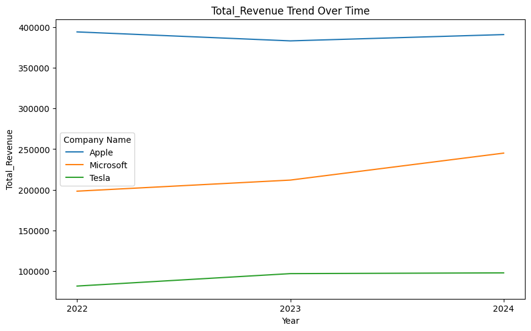

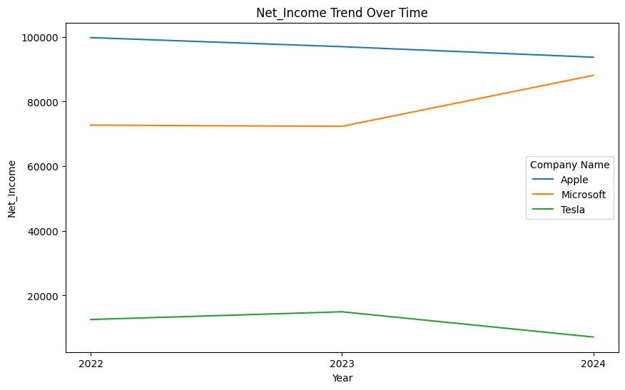

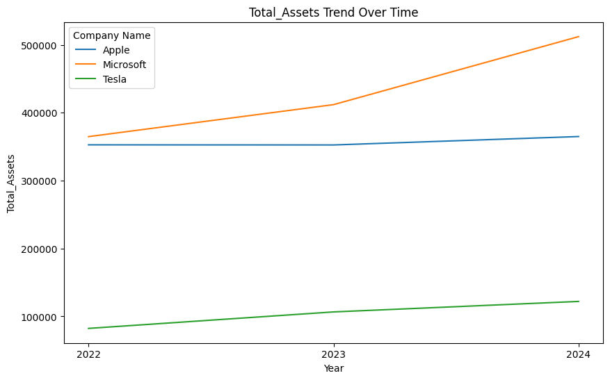

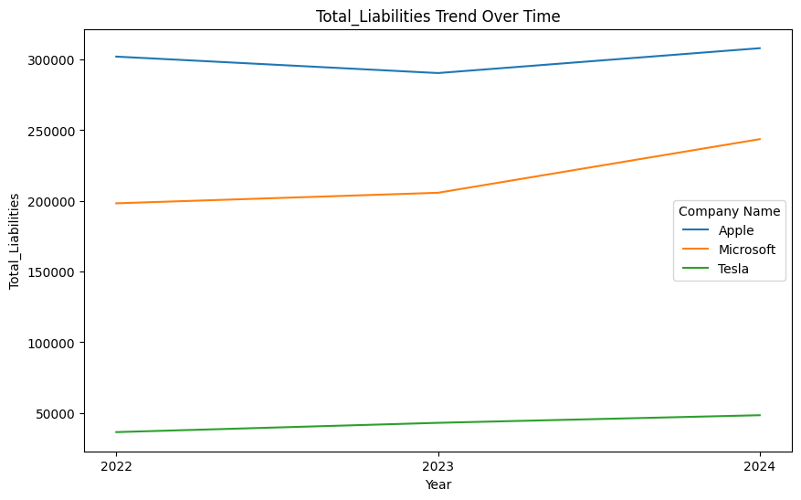

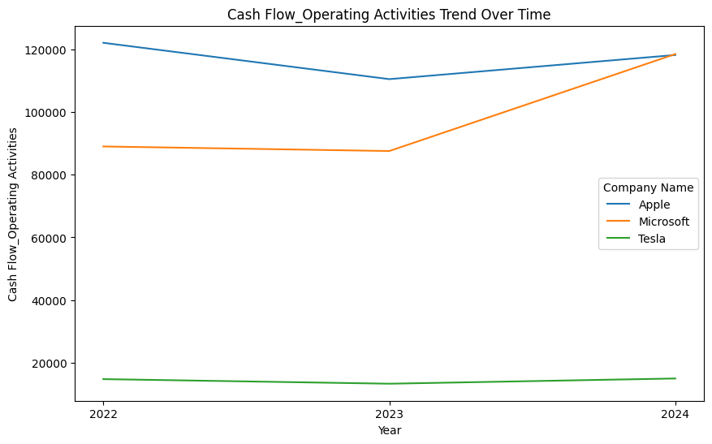

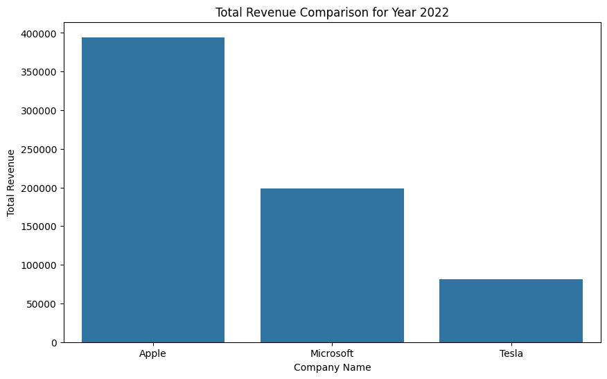

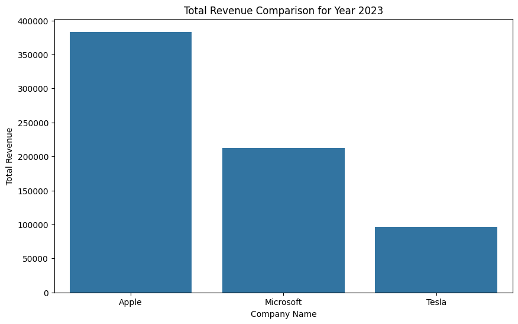

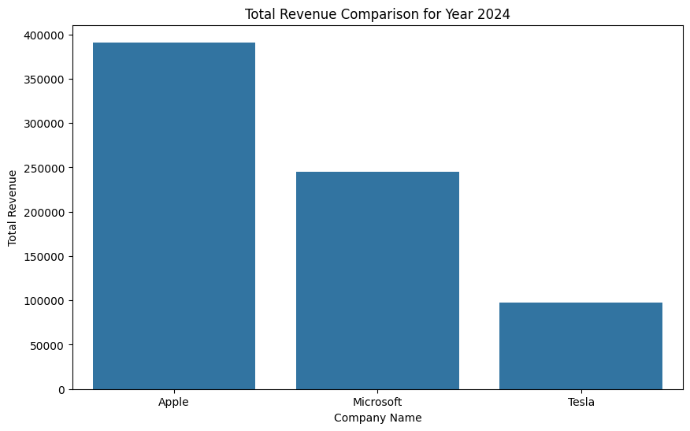

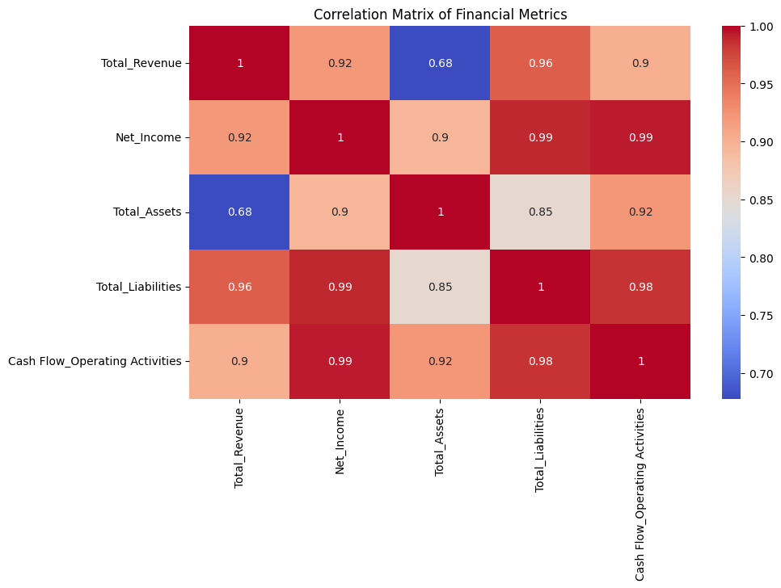

```python
# 1. Line plots for each financial metric over time
for metric in ['Total_Revenue', 'Net_Income', 'Total_Assets', 'Total_Liabilities', 'Cash Flow_Operating Activities']:
    plt.figure(figsize=(10, 6))
    sns.lineplot(x='Year', y=metric, hue='Company_Name', data=company_year_stats.reset_index())
    plt.title(f'{metric} Trend Over Time')
    plt.xlabel('Year')
    plt.ylabel(metric)
    plt.legend(title='Company Name')
    # Convert x-axis ticks to integers
    plt.xticks(company_year_stats.reset_index()['Year'].unique().astype(int))
    plt.show()

# 2. Bar plots for comparing financial metrics across companies for each year
for year in company_year_stats.reset_index()['Year'].unique():
    plt.figure(figsize=(10, 6))
    sns.barplot(x='Company_Name', y='Total_Revenue', data=company_year_stats.reset_index()[company_year_stats.reset_index()['Year'] == year])
    plt.title(f'Total Revenue Comparison for Year {int(year)}')  # Convert year to integer in title
    plt.xlabel('Company Name')
    plt.ylabel('Total Revenue')
    plt.show()

# 3. Heatmap to visualize the correlation between financial metrics
plt.figure(figsize=(10, 6))
sns.heatmap(company_year_stats.corr(), annot=True, cmap='coolwarm')
plt.title('Correlation Matrix of Financial Metrics')
plt.show()
```

## Analyzing Trends:

Calculate growth percentages and add them as new columns

```python
# Calculating growth percentages and adding them as new columns

# Function to calculate year-over-year growth percentage
def calculate_growth_percentage(df, column):
  """Calculates year-over-year growth percentage for a given column."""
  df[column + ' Growth %'] = df.groupby('Company_Name')[column].pct_change() * 100
  return df


# Applying the function to each financial metric
for column in ['Total_Revenue', 'Net_Income', 'Total_Assets', 'Total_Liabilities', 'Cash Flow_Operating Activities']:
  data = calculate_growth_percentage(data, column)

# Calculate the growth trends using the new columns
growth_trends = data.groupby('Company_Name').agg(
    revenue_growth=('Total_Revenue Growth %', 'mean'),
    profit_growth=('Net_Income Growth %', 'mean'),
    asset_growth=('Total_Assets Growth %', 'mean'),
    liabilities_growth=('Total_Liabilities Growth %', 'mean'),
    # Change the column name to match the one created in calculate_growth_percentage function
    cash_flow_growth=('Cash Flow_Operating Activities Growth %', 'mean')
)

# Displaying the growth trends
print("Growth Trend Over 3 Fiscal Years for Each Company:")
print(growth_trends)

print("\nGrowth Trend (Transposed):")
print(growth_trends.T)
```

```
Growth Trend Over 3 Fiscal Years for Each Company:
              revenue_growth  profit_growth  asset_growth  liabilities_growth  \
Company_Name
Apple                  -0.39          -3.09          1.73                1.10
Microsoft              11.28          10.64         18.62               11.10
Tesla                   9.87         -16.63         21.99               15.27

              cash_flow_growth
Company_Name
Apple                    -1.26
Microsoft                16.86
Tesla                     1.30

Growth Trend (Transposed):
Company_Name        Apple  Microsoft  Tesla
revenue_growth      -0.39      11.28   9.87
profit_growth       -3.09      10.64 -16.63
asset_growth         1.73      18.62  21.99
liabilities_growth   1.10      11.10  15.27
cash_flow_growth    -1.26      16.86   1.30
```

### Summary Findings

Revenue Growth:

- Revenue growth was strongest for Microsoft, averaging 11.28% over the three years. This would imply that the market is well-expanding and that there is successful offering of product/service offerings.
- Tesla showed really impressive revenue growth, averaging 9.87%, driven by continuous demand for electric vehicles and other energy solutions.
- Apple represented a slight decrease in revenue, with an average growth of -0.39% average. This may signify that saturation is beginning to set in, or there is increased competition in the core product segments.

Profit Growth:

- Microsoft again leads the way, with an impressive average profit growth of 10.64%, reflecting operational efficiency and the capability to translate revenues into earnings.
- Apple experienced an average profit growth of -3.09% probably due to increased production costs or price pressures
- Tesla's profit growth drastically fell on average by -16.63%, probably because of investment in research and development, expansion, or competitive pressures.

Asset Growth:

- The maximum asset growth stood by Tesla at 21.99% due to immense investments in manufacturing capacity, infrastructure, and new technologies..
- Microsoft also showed impressive asset growth of 18.62% average; this would most likely result from acquisitions, expansion efforts, and heavy cloud infrastructure investments.
- Apple had an asset growth moderated at 1.73 percent, which indicated that Apple has been more conservative in terms of capital expenditure versus the other two companies.

Liabilities Growth:

- Tesla showed the biggest growth of liabilities by 15.27%, probably due to debt financing which was necessary for such rapid expansion.
- Microsoft also tends to increase its average liabilities by 11.10%, reflecting strategic investments and acquisitions.
- Apple has comparative low growth of liabilities at 1.10%, probably a manifestation of the far more conservative attitude toward debt financing.

Cash Flow from Operating Activities Growth:

- Microsoft's cash flow from operating activities increased the most, at 16.86%, reflecting healthy cash generation from core operations.
- Tesla experienced modest growth in cash flow from operating activities at 1.30%, suggesting potential challenges in translating revenue growth into consistent cash flow.
- Apple faced a decline in cash flow from operating activities growth, averaging -1.26%, which could be due to factors like changes in working capital or investment cycles.

### Methodology, Observations, and Conclusions

### Methodology

- The 10-K Financial data for 3 fiscal years (2022,2023, and 2024) were examined and five data points were selected for the data analysis. These data points (metrics) were Total Revenue, Net Income, Total Assets, Total Liabilities, and Cash Flow from Operating Activities.
- The data extracted from these financial statements were put into an excel spreadsheet, which was subsequently converted into a Comma Seperated Value(CSV) file for easier handling and then loaded into a dataframe.
- The objective for performing the analysis was provided, including the data description and data dictionary.
- The necessary files were imported to help with data manipulation and visualization, as well as loading the dataset to help with the analysis.
- The data was checked for missing and duplicated values to ensure its readiness and integrity for analysis.
- Year was converted into an object or categorical variable.

### Observations

- The data provided shows the growth trend over three fiscal years for Apple, Microsoft, and Tesla across several financial metrics: revenue growth, profit growth, asset growth, liabilities growth, and cash flow growth.
- The transposed table makes it easier to compare the companies side-by-side for each financial metric. These have been highlighted in the summary findings.
- There is a strong correlation among the financial metrics as can be seen from the heatmap.

### Conclusions

- Microsoft is the strongest performer, demonstrating healthy financial growth across all financial metrics.
- Tesla shows high revenue and asset growth but struggles with profitability and a rising liability burden. This suggests a growth-focused strategy that may be sacrificing profits in the short term.
- Apple shows concerning trends with declining revenue, profit, and cash flow. These issues need to be addressed to ensure future growth.
- Growth rates can be compared to industry averages to see how these firms are performing against their competitors.